# Blog

## La constitution des réserves de nourriture pour les futures larves

Il est très intéressant d’observer le va et vient des abeilles sauvages quand elles commencent à constituer les réserves de nourritures. **Lorsqu’elles arrivent avec des paquets de pollens accrochés aux pattes arrières, elles entrent dans le trou à reculons**, déposent leurs fardeaux et repartent en marche avant pour aller chercher un nouveau chargement.

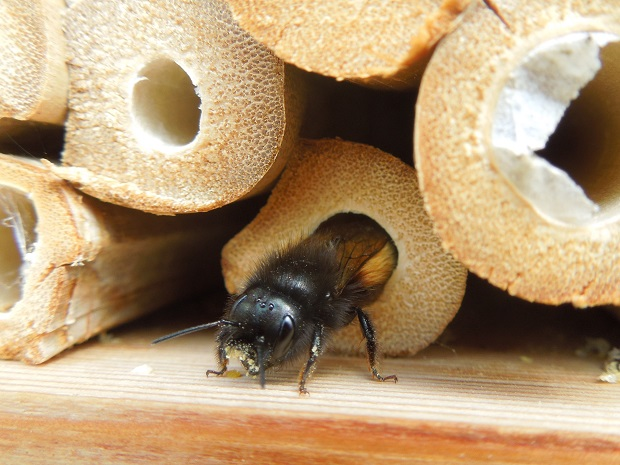

**Si c’est du nectar qu’elles ramènent, elles rentrent dans le trou en marche avant**, régurgitent le nectar dans la loge et ressortent à reculons, le trou étant trop exigu pour faire demi-tour.

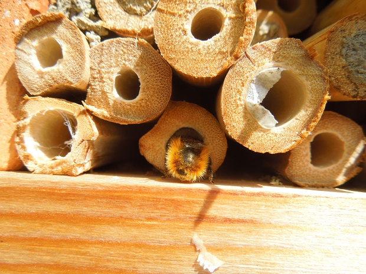

C’est en les observant que je me suis aperçue qu’elles entraient parfois en marche avant et parfois en marche arrière. Je me suis dit qu’il y avait sans doute une bonne raison à cela et après enquête j’ai compris pourquoi. C’est vraiment fascinant de les observer. Tout comme les mâles, les femelles sont très faciles à photographier parce qu’elles sont exclusivement occupées à leur nid et se moquent complètement de ce qu’il se passe autour. Elles sont plus grosses que les mâles et n’ont pas de toupet blanc sur la tête. Par contre, elles sont pourvue d’une petite corne en-dessous de chaque antenne, d’où leur nom d’osmies cornues. Je peux passer plusieurs minutes à les observer, c’est passionnant c’est aussi bénéfique qu’une séance de méditation.

## Quelques travaux de maçonnerie plus tard…

Après quelques jours de travail intense, les abeilles sauvages ont occupé presque tous les trous mis à leur disposition. Les logements vacants se font rares et donnent parfois lieu à des disputes à propos des titres de propriété. **Les loges resteront fermées avec leur bouchon de mortier fait de terre et de salive jusqu’au printemps suivant.** Les larves s’y transformeront progressivement en abeilles sauvages qui sortiront au grand air dès le mois de mars pour recommencer un nouveau cycle. Ne débouchez pas les trous bouchés, laissez faire les abeilles, même si un œuf n’a finalement pas donné naissance à une larve, les abeilles sauvages se chargeront de nettoyer la loge et de faire le nécessaire pour que la place soit à nouveau disponible.

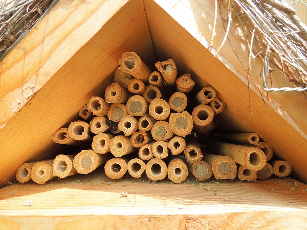

Faites-vous plaisir en construisant un petit abri pour les insectes et faites ainsi un geste pour l’environnement et pour le maintien de la biodiversité tant au niveau de la faune que de la flore. Je vous recommande le livre « Construire un hôtel à insectes » de Wolf Richard Günzel aux éditions La Plage. Vous trouverez toutes les informations nécessaires pour construire un hôtel à insectes généraliste ou un abri spécifique d’une espèce donnée et vous apprendrez aussi beaucoup sur les habitudes de vie des différents insectes. La vie est un subtil équilibre qu’il faut respecter. Nous ne sommes ni plus importants ni moins importants que les abeilles sauvages. Tout comme elles nous faisons partie du tout.

Prenez soin de vous et de votre environnement,

Isabelle.

Photos : Isabelle Ducau

[figure not shown]

Sylvia beugnies

23 avril 2024 22 h 40 min

Merci beaucoup pour ces explications ça m’a permis de mieux observé les abeilles

Dernière modification le 9 mois il y a par Sylvia beugnies

Répondre

Auteur

[Isabelle](http://lescarnetsdubienetre.com/)

27 avril 2024 7 h 47 min

Répondre à Sylvia beugnies

Avec plaisir Sylvia 🙂

Répondre

Benoît

1 avril 2024 17 h 14 min

Merci beaucoup pour ces explications ! C est vraiment très intéressant ça m’ a permis de mieux comprendre mes observations, par exemple pourquoi elles rentrent d un sens puis d un autre…

Répondre

Auteur

[Isabelle](http://lescarnetsdubienetre.com/)

1 avril 2024 19 h 43 min

Répondre à Benoît

Avec plaisir !  
Isabelle

Répondre

H.R.

13 mai 2023 17 h 00 min

Bonjour,  
Sauriez-vous comment déplacer un hôtel à insectes ? J’aimerais inclure mon petit hôtel (complètement colonisé par les osmies sur mon balcon) dans un plus grand (pour les protéger davantage et leur permettre d’agrandir la colonie).  
Mais je redoute la manipulation de l’hôtel…  
A quelle saison ne pas les déranger ?  
Hibernent-elles ?  
vos conseils sont bien venus.

Répondre

Auteur

[Isabelle](http://lescarnetsdubienetre.com/)

18 mai 2023 19 h 21 min

Répondre à H.R.

Bonjour,  
Vu que les abeilles sont actives jusqu’à la fin de l’été, je pense que le mieux est de le déplacer à partir d’octobre ou pendant l’hiver. Veiller à l’installer plein sud. Pendant cette période il m’y a quitté des larves en cours de développement donc pas de risques de perturber les insectes. Comme indiqué dans l’article, les abeilles n’hibernent pas, elles meurent en fin de saison. Les larves assurent la génération suivante.

Répondre

Nicole

14 septembre 2022 22 h 12 min

Bonjour,  
Je ne comprends pas en combien de temps les abeilles solitaires se forment une fois le trou refermé, moi les trous étaient bouchés au printemps et je viens de voir que tous les trous sont ouverts!… est ce normal ? … Merci de m’informer

Répondre

Auteur

[Isabelle](http://lescarnetsdubienetre.com/)

15 septembre 2022 6 h 49 min

Répondre à Nicole

Bonjour Nicole,  
Les abeilles pondent leurs œufs dans les tiges au printemps puis elles obturent le trou. Les larves se développent jusqu’au printemps suivant et lorsqu’elles sont complètement formées, elles ouvrent l’opercule et sortent en général à partir de mars ou avril selon les températures.  
Si les trous sont ouverts maintenant c’est qu’il n’y a pas eu de ponte au printemps 2022.  
Isabelle

Répondre

Pascal

17 mai 2022 15 h 59 min

Bonjour Isabelle, merci pour votre excellente description du cycle des abeilles sauvages. Situé à Bruxelles, mon hôtel a vu un défilé ininterrompu d’abeilles rousses pendant le mois d’avril. Puis début mai elles ont disparu. Est-ce normal ou bien auraient-elles été victimes d’un pesticide dans le voisinage? Merci de votre avis.

Répondre

Auteur

[Isabelle](http://lescarnetsdubienetre.com/)

22 juin 2022 9 h 40 min

Répondre

Jérôme mercier

2 mai 2022 12 h 48 min

Oups j’ai oublié la pièce jointe

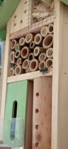

Répondre

Auteur

[Isabelle](http://lescarnetsdubienetre.com/)

2 mai 2022 15 h 02 min

Répondre à Jérôme mercier

Bonjour Jérôme,  
Je ne suis pas une spécialiste des abeilles. Sur la photo on dirait qu’il y a du blanc. Les mâles osmies rousses ont du blanc mais franchement je ne peux pas vous dire. Peut-être qu’un apiculteur pourrait ? Tout ce que je peux dire c’est qu’après recherches sur le net et observations, « mes » abeilles sont des osmies rousses. Bonne recherche et quoi qu’il en soit c’est super chouette de leur offrir un gîte ! Bravo à vous !  
Isabelle

Répondre

Jérôme mercier

2 mai 2022 18 h 35 min

Répondre à Isabelle

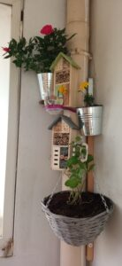

Répondre

Jérôme mercier

2 mai 2022 18 h 38 min

Répondre à Isabelle

Le bac d’eau que j’ai posé ne me semble pas une bonne idée. Elle est tombé dedans la pauvre . Je l’ai sortie avec un papier et mise au soleil ouf… Sauvée

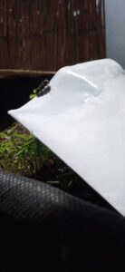

Répondre

Auteur

[Isabelle](http://lescarnetsdubienetre.com/)

2 mai 2022 19 h 09 min

Répondre à Jérôme mercier

En effet, ce n’est pas utile. Les abeilles boivent le nectar des fleurs. Bravo pour votre installation ! C’est la pleine saison de ponte. L’année prochaine, en mars, vous verrez sortir des loges la première génération de vos hôtels 😉

Répondre

Jérôme mercier

2 mai 2022 12 h 46 min

Bonjour . Sauriez vous me dire de quelle race d’abeille il s’agit ? Je cherche, je cherche.. rien ne correspond. Ps: j’habite les quartiers nord de Marseille . Merci.

Répondre

Anthony

20 septembre 2020 11 h 05 min

Bonjour,  
J’ai lu l’article et j’ai une question.  
Cette année tous les trous de mon hôtel à insecte sont restés bouchés, aucun abeille n’est sortie. Quel peut-être le problème ?

Répondre

Auteur

[Isabelle](http://lescarnetsdubienetre.com/)

20 septembre 2020 17 h 11 min

Répondre

nouria

13 juillet 2020 14 h 11 min

Répondre

Auteur

[Isabelle](http://lescarnetsdubienetre.com/)

18 juillet 2020 14 h 52 min

Répondre à nouria

Bonjour Nouria,  
Merci pour votre message. Je ne suis pas une spécialiste des abeilles. Concernant les osmies cornues, c’est parce que je les ai observées que j’ai décidé de faire des recherches pour mieux comprendre leur mode de vie. J’ai ensuite partagé ce que j’avais appris ici. A partir de photos de vos abeilles, vous pourrez sans doute trouver sur le net de quelle espèce il s’agit et en apprendre un peu plus sur vos pensionnaires ! Peut-être que ce document pourra vous aider … [les nids d’abeilles solitaires et sociales](http://www7.inra.fr/opie-insectes/pdf/i137villemant.pdf)  
Bonne observation 🙂  
Isabelle

Répondre

Stéphan

16 avril 2020 22 h 33 min

Répondre

Auteur

[Isabelle](http://lescarnetsdubienetre.com/)

17 avril 2020 19 h 14 min

Répondre à Stéphan

Merci Stéphan,  
Les osmies de mon hôtel ont beaucoup de fleurs à proximité et effectivement elles utilisent la terre du jardin qu’elles mélangent à leur salive pour fabriquer leur mortier, ce sont de vraies maçonnes !!

Répondre

CLAUDE

12 avril 2020 18 h 05 min

J’ai deux hotels à insectes c’est un plaisir de les regarder faire j’ai beaucoup de lauriers deux cerisiers et un prunier des multitudes de pâquerettes…

Répondre

Auteur

[Isabelle](http://lescarnetsdubienetre.com/)

15 avril 2020 11 h 16 min

Répondre à CLAUDE

Oui Claude, les insectes sont fascinants !

Répondre

Véronique

2 avril 2020 11 h 53 min

Bonjour Isabelle,  
Merci pour tous ces précieux renseignements  
Moi aussi je passe du temps à les regarder , nous avons installés des hôtels à insectes et notre récompense c’est de les voir œuvrer.  
Je trouve cela fascinant et me procure un grand plaisir.  
Vous souhaitant une belle journée  
Bien cordialement,

Véronique

Répondre

Auteur

[Isabelle](http://lescarnetsdubienetre.com/)

2 avril 2020 15 h 03 min

Répondre à Véronique

Merci Véronique, en ce moment elles sont en pleine activité dans notre hôtel !

Répondre

Frédéric

1 juin 2019 19 h 25 min

Bonsoir Isabelle,  
Excellent article très instructif et très bien rédigé !  
C’est grâce à votre article que j’ai compris pourquoi des bouchons de mortier commençaient à apparaître sur mon hôtel à insectes.  
Je viens aussi d’installer des larves de coccinelles sur des plantes colonisés par les pucerons.  
Merci pour votre analyse et votre sens aiguë de l’observation !  
Frédéric

Répondre

Auteur

[Isabelle](http://lescarnetsdubienetre.com/)

17 juin 2019 13 h 31 min

Répondre à Frédéric

Merci beaucoup Frédéric 🙂

Répondre

Agnès

23 avril 2019 17 h 00 min

J’adore votre article qui m’a beaucoup appris sur les osmies, mes arbres fruitiers ne sont pas très visités, je compte sur les nouvelles générations d’osmies de mon hotel à insectes pour avoir plus de fruits. C’est du donnant donnant et c’est plus facile que d’avoir des ruches.  
Merci, continuez à partager, vous le faites bien.

Répondre

Auteur

[Isabelle](http://lescarnetsdubienetre.com/)

23 avril 2019 17 h 07 min

Répondre à Agnès

Merci pour votre commentaire Agnès et bravo pour votre soutien à la biodiversité !

Répondre

Julie

9 juillet 2017 11 h 40 min

Merci pour ces informations très intéressantes. J’ai installé un hôtel à insectes sur mon balcon, mais nous déménageons et je voulais en apprendre un peu plus sur le sujet pour ne pas perturber les abeilles qui ont fait des nids. Les trous sont presque tous bouchés, j’imagine que les abeilles écloront au printemps prochain sur ma nouvelle terrasse.

Répondre

Auteur

[Isabelle](http://lescarnetsdubienetre.com/)

10 juillet 2017 18 h 48 min

Répondre

Mion

28 mars 2017 10 h 46 min

je crois que c’est Jean Henri Fabre qui le premier eut l’idée de réaliser un hôtel de ce genre.  
Une chose curieuse : par la force des choses il faut que les larves qui sont près de la sortie de l’orifice éclosent et sortent les premières. C’est à dire que les osmies font en sorte que l’ordre d’éclosion soit inverse de l’ordre de ponte : les larves les plus récentes doivent sortir les premières, les premières pondues en dernier.

Répondre

Auteur

[Isabelle](http://lescarnetsdubienetre.com/)

28 mars 2017 13 h 26 min

Répondre à Mion

Oui Alain, la nature est très bien faite. Les Osmies pondent d’abord les œufs fécondés qui donneront les femelles puis les œufs non fécondés qui donneront les mâles et seront les plus proches de la sortie !

Répondre

Priscilla

9 février 2018 19 h 25 min

Répondre à Isabelle

Mes abeilles commencent à sortir de leur trou alors que nous sommes en février il fait -2 degrés

Répondre

Auteur

[Isabelle](http://lescarnetsdubienetre.com/)

12 février 2018 15 h 23 min

Répondre à Priscilla

Bonjour Priscilla,  
En effet, c’est un peu tôt… Les miennes sont encore à l’abri pour le moment.

Répondre

Dominique

27 mars 2017 20 h 33 min

Merci Isabelle pour ce beau reportage. Le monde des abeilles est fascinant. …C’est toujours un plaisir de vous lire. Belle continuation Dominique

Répondre

Auteur

[Isabelle](http://lescarnetsdubienetre.com/)

28 mars 2017 7 h 36 min

Répondre à Dominique

Merci Dominique 🙂

Répondre

#### Bonjour !

Sophrologue en Nord-Isère, ceci est mon blogue personnel.

Bienvenue chez moi ! Je vous partage des outils, des réflexions, des divertissements... Alors lisez, partagez, commentez, soyez curieux et ouverts !